# Risk Factor Analysis

## Outcome Variable

**Outcome Variable:** ever_sstunted

## Predictor Variables

**Intervention Variable:** mbmi

**Adjustment Set:**

- arm
- W_mage
- meducyrs
- feducyrs
- hhwealth_quart
- W_nrooms
- W_nchldlt5
- brthmon
- W_parity
- impfloor
- impsan
- safeh20
- delta_W_mage
- delta_meducyrs
- delta_feducyrs
- delta_hhwealth_quart
- delta_W_nrooms
- delta_W_nchldlt5
- delta_brthmon
- delta_W_parity
- delta_impfloor
- delta_impsan
- delta_safeh20

## Stratifying Variables

The analysis was stratified on these variable(s):

- agecat
- studyid
- country

## Data Summary

| agecat | studyid | country | mbmi | ever_sstunted | n_cell | n |
| --- | --- | --- | --- | --- | --- | --- |
| 0-24 months | iLiNS-Zinc | BURKINA FASO | Normal weight | 0 | 2480 | 3216 |
| 0-24 months | iLiNS-Zinc | BURKINA FASO | Normal weight | 1 | 282 | 3216 |
| 0-24 months | iLiNS-Zinc | BURKINA FASO | Underweight | 0 | 398 | 3216 |
| 0-24 months | iLiNS-Zinc | BURKINA FASO | Underweight | 1 | 56 | 3216 |
| 0-24 months | JiVitA-3 | BANGLADESH | Normal weight | 0 | 13500 | 27105 |
| 0-24 months | JiVitA-3 | BANGLADESH | Normal weight | 1 | 3222 | 27105 |
| 0-24 months | JiVitA-3 | BANGLADESH | Underweight | 0 | 8606 | 27105 |
| 0-24 months | JiVitA-3 | BANGLADESH | Underweight | 1 | 1777 | 27105 |
| 0-24 months | LCNI-5 | MALAWI | Normal weight | 0 | 550 | 837 |
| 0-24 months | LCNI-5 | MALAWI | Normal weight | 1 | 142 | 837 |
| 0-24 months | LCNI-5 | MALAWI | Underweight | 0 | 110 | 837 |
| 0-24 months | LCNI-5 | MALAWI | Underweight | 1 | 35 | 837 |
| 0-24 months | MAL-ED | BANGLADESH | Normal weight | 0 | 176 | 254 |
| 0-24 months | MAL-ED | BANGLADESH | Normal weight | 1 | 46 | 254 |
| 0-24 months | MAL-ED | BANGLADESH | Underweight | 0 | 22 | 254 |
| 0-24 months | MAL-ED | BANGLADESH | Underweight | 1 | 10 | 254 |
| 0-24 months | MAL-ED | BRAZIL | Normal weight | 0 | 192 | 221 |
| 0-24 months | MAL-ED | BRAZIL | Normal weight | 1 | 19 | 221 |
| 0-24 months | MAL-ED | BRAZIL | Underweight | 0 | 8 | 221 |
| 0-24 months | MAL-ED | BRAZIL | Underweight | 1 | 2 | 221 |
| 0-24 months | MAL-ED | INDIA | Normal weight | 0 | 148 | 242 |
| 0-24 months | MAL-ED | INDIA | Normal weight | 1 | 45 | 242 |
| 0-24 months | MAL-ED | INDIA | Underweight | 0 | 36 | 242 |
| 0-24 months | MAL-ED | INDIA | Underweight | 1 | 13 | 242 |
| 0-24 months | MAL-ED | NEPAL | Normal weight | 0 | 217 | 238 |
| 0-24 months | MAL-ED | NEPAL | Normal weight | 1 | 21 | 238 |
| 0-24 months | MAL-ED | NEPAL | Underweight | 0 | 0 | 238 |
| 0-24 months | MAL-ED | NEPAL | Underweight | 1 | 0 | 238 |
| 0-24 months | MAL-ED | PERU | Normal weight | 0 | 225 | 290 |
| 0-24 months | MAL-ED | PERU | Normal weight | 1 | 60 | 290 |

[output cut: 102 more lines]

The following strata were considered:

- agecat: 0-24 months, studyid: iLiNS-Zinc, country: BURKINA FASO
- agecat: 0-24 months, studyid: JiVitA-3, country: BANGLADESH
- agecat: 0-24 months, studyid: LCNI-5, country: MALAWI
- agecat: 0-24 months, studyid: MAL-ED, country: BANGLADESH
- agecat: 0-24 months, studyid: MAL-ED, country: BRAZIL
- agecat: 0-24 months, studyid: MAL-ED, country: INDIA
- agecat: 0-24 months, studyid: MAL-ED, country: NEPAL
- agecat: 0-24 months, studyid: MAL-ED, country: PERU
- agecat: 0-24 months, studyid: MAL-ED, country: SOUTH AFRICA
- agecat: 0-24 months, studyid: MAL-ED, country: TANZANIA, UNITED REPUBLIC OF
- agecat: 0-24 months, studyid: NIH-Birth, country: BANGLADESH
- agecat: 0-24 months, studyid: NIH-Crypto, country: BANGLADESH
- agecat: 0-24 months, studyid: PROBIT, country: BELARUS
- agecat: 0-24 months, studyid: PROVIDE, country: BANGLADESH
- agecat: 0-24 months, studyid: SAS-CompFeed, country: INDIA
- agecat: 0-24 months, studyid: TanzaniaChild2, country: TANZANIA, UNITED REPUBLIC OF
- agecat: 0-24 months, studyid: ZVITAMBO, country: ZIMBABWE
- agecat: 0-6 months, studyid: JiVitA-3, country: BANGLADESH
- agecat: 0-6 months, studyid: LCNI-5, country: MALAWI
- agecat: 0-6 months, studyid: MAL-ED, country: BANGLADESH
- agecat: 0-6 months, studyid: MAL-ED, country: BRAZIL
- agecat: 0-6 months, studyid: MAL-ED, country: INDIA
- agecat: 0-6 months, studyid: MAL-ED, country: NEPAL
- agecat: 0-6 months, studyid: MAL-ED, country: PERU
- agecat: 0-6 months, studyid: MAL-ED, country: SOUTH AFRICA
- agecat: 0-6 months, studyid: MAL-ED, country: TANZANIA, UNITED REPUBLIC OF
- agecat: 0-6 months, studyid: NIH-Birth, country: BANGLADESH
- agecat: 0-6 months, studyid: NIH-Crypto, country: BANGLADESH
- agecat: 0-6 months, studyid: PROBIT, country: BELARUS
- agecat: 0-6 months, studyid: PROVIDE, country: BANGLADESH
- agecat: 0-6 months, studyid: SAS-CompFeed, country: INDIA
- agecat: 0-6 months, studyid: TanzaniaChild2, country: TANZANIA, UNITED REPUBLIC OF
- agecat: 0-6 months, studyid: ZVITAMBO, country: ZIMBABWE

### Dropped Strata

Some strata were dropped due to rare outcomes:

- agecat: 0-24 months, studyid: MAL-ED, country: BRAZIL
- agecat: 0-24 months, studyid: MAL-ED, country: NEPAL
- agecat: 0-24 months, studyid: MAL-ED, country: PERU
- agecat: 0-24 months, studyid: MAL-ED, country: SOUTH AFRICA
- agecat: 0-24 months, studyid: TanzaniaChild2, country: TANZANIA, UNITED REPUBLIC OF
- agecat: 0-6 months, studyid: LCNI-5, country: MALAWI
- agecat: 0-6 months, studyid: MAL-ED, country: BANGLADESH
- agecat: 0-6 months, studyid: MAL-ED, country: BRAZIL
- agecat: 0-6 months, studyid: MAL-ED, country: NEPAL
- agecat: 0-6 months, studyid: MAL-ED, country: PERU
- agecat: 0-6 months, studyid: MAL-ED, country: SOUTH AFRICA
- agecat: 0-6 months, studyid: MAL-ED, country: TANZANIA, UNITED REPUBLIC OF
- agecat: 0-6 months, studyid: PROVIDE, country: BANGLADESH
- agecat: 0-6 months, studyid: TanzaniaChild2, country: TANZANIA, UNITED REPUBLIC OF

## Methods Detail

We’re interested in the causal parameters $E[Y_a]$ for all values of $a \in \mathcal{A}$. These parameters represent the mean outcome if, possibly contrary to fact, we intervened to set all units to have $A=a$. Under the randomization and positivity assumptions, these are identified by the statistical parameters $\psi_a=E_W[E_{Y|A,W}(Y|A=a,W)]$. In addition, we’re interested in the mean of $Y$, $E[Y]$ under no intervention (the observed mean). We will estimate these parameters by using SuperLearner to fit the relevant likelihood factors – $E_{Y|A,W}(Y|A=a,W)$ and $p(A=a|W)$, and then updating our likelihood fit using a joint TMLE.

For unadjusted analyses ($W=\{\}$), initial likelihoods were estimated using Lrnr_glm to estimate the simple $E(Y|A)$ and Lrnr_mean to estimate $p(A)$. For adjusted analyses, a small library containing Lrnr_glmnet, Lrnr_xgboost, and Lrnr_mean was used.

Having estimated these parameters, we will then use the delta method to estimate relative risks and attributable risks relative to a prespecified baseline level of $A$.

# Results Detail

## Results Plots

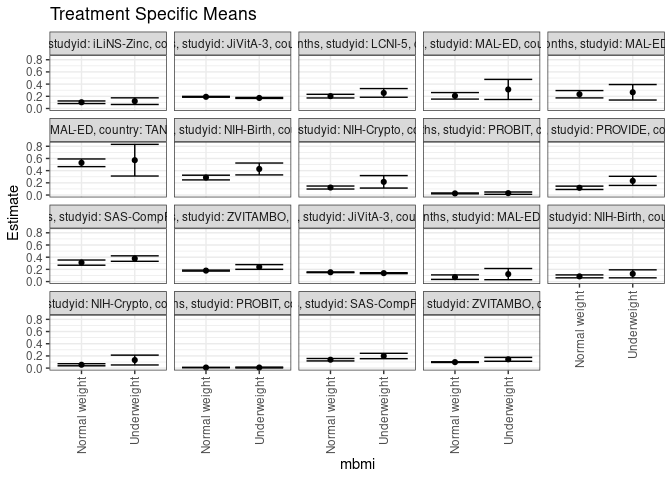

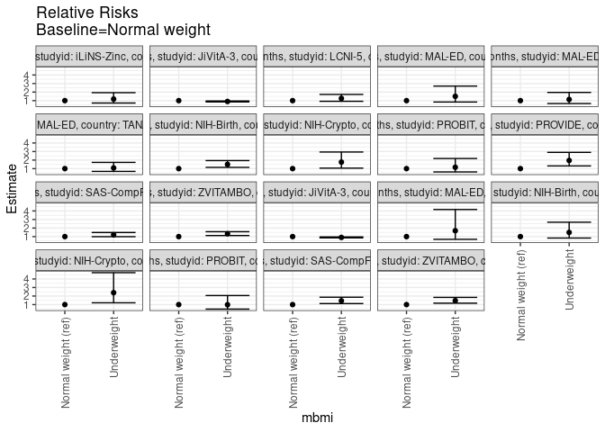

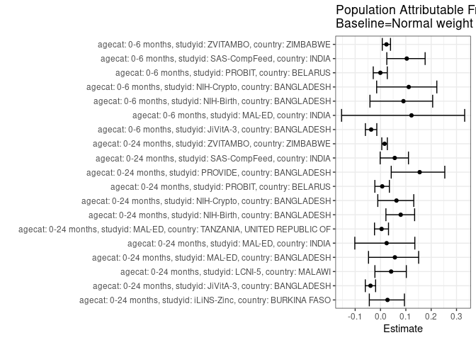

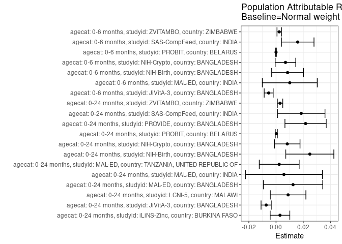

## Results Table

### Parameter: TSM

| agecat | studyid | country | intervention_level | baseline_level | estimate | ci_lower | ci_upper |
| --- | --- | --- | --- | --- | --- | --- | --- |
| 0-24 months | iLiNS-Zinc | BURKINA FASO | Normal weight | NA | 0.1021948 | 0.0811556 | 0.1232340 |
| 0-24 months | iLiNS-Zinc | BURKINA FASO | Underweight | NA | 0.1207299 | 0.0662301 | 0.1752297 |
| 0-24 months | JiVitA-3 | BANGLADESH | Normal weight | NA | 0.1917088 | 0.1848067 | 0.1986109 |
| 0-24 months | JiVitA-3 | BANGLADESH | Underweight | NA | 0.1728328 | 0.1647861 | 0.1808796 |
| 0-24 months | LCNI-5 | MALAWI | Normal weight | NA | 0.2026007 | 0.1725825 | 0.2326189 |
| 0-24 months | LCNI-5 | MALAWI | Underweight | NA | 0.2556578 | 0.1845551 | 0.3267605 |
| 0-24 months | MAL-ED | BANGLADESH | Normal weight | NA | 0.2079519 | 0.1544093 | 0.2614945 |
| 0-24 months | MAL-ED | BANGLADESH | Underweight | NA | 0.3125028 | 0.1476695 | 0.4773361 |
| 0-24 months | MAL-ED | INDIA | Normal weight | NA | 0.2338694 | 0.1738846 | 0.2938541 |
| 0-24 months | MAL-ED | INDIA | Underweight | NA | 0.2659951 | 0.1390094 | 0.3929809 |
| 0-24 months | MAL-ED | TANZANIA, UNITED REPUBLIC OF | Normal weight | NA | 0.5289256 | 0.4659123 | 0.5919389 |
| 0-24 months | MAL-ED | TANZANIA, UNITED REPUBLIC OF | Underweight | NA | 0.5714286 | 0.3116959 | 0.8311612 |
| 0-24 months | NIH-Birth | BANGLADESH | Normal weight | NA | 0.2867497 | 0.2480055 | 0.3254939 |
| 0-24 months | NIH-Birth | BANGLADESH | Underweight | NA | 0.4275733 | 0.3305344 | 0.5246123 |
| 0-24 months | NIH-Crypto | BANGLADESH | Normal weight | NA | 0.1228661 | 0.0982733 | 0.1474589 |
| 0-24 months | NIH-Crypto | BANGLADESH | Underweight | NA | 0.2165604 | 0.1143778 | 0.3187429 |
| 0-24 months | PROBIT | BELARUS | Normal weight | NA | 0.0269133 | 0.0195806 | 0.0342461 |
| 0-24 months | PROBIT | BELARUS | Underweight | NA | 0.0311435 | 0.0123897 | 0.0498974 |
| 0-24 months | PROVIDE | BANGLADESH | Normal weight | NA | 0.1187828 | 0.0914740 | 0.1460916 |
| 0-24 months | PROVIDE | BANGLADESH | Underweight | NA | 0.2322614 | 0.1574869 | 0.3070359 |
| 0-24 months | SAS-CompFeed | INDIA | Normal weight | NA | 0.3112436 | 0.2687605 | 0.3537267 |
| 0-24 months | SAS-CompFeed | INDIA | Underweight | NA | 0.3774407 | 0.3327653 | 0.4221161 |
| 0-24 months | ZVITAMBO | ZIMBABWE | Normal weight | NA | 0.1799666 | 0.1721528 | 0.1877805 |
| 0-24 months | ZVITAMBO | ZIMBABWE | Underweight | NA | 0.2396238 | 0.2008238 | 0.2784239 |
| 0-6 months | JiVitA-3 | BANGLADESH | Normal weight | NA | 0.1527000 | 0.1466511 | 0.1587489 |
| 0-6 months | JiVitA-3 | BANGLADESH | Underweight | NA | 0.1384325 | 0.1310486 | 0.1458164 |
| 0-6 months | MAL-ED | INDIA | Normal weight | NA | 0.0725389 | 0.0358696 | 0.1092081 |
| 0-6 months | MAL-ED | INDIA | Underweight | NA | 0.1224490 | 0.0304754 | 0.2144225 |
| 0-6 months | NIH-Birth | BANGLADESH | Normal weight | NA | 0.0853094 | 0.0612587 | 0.1093602 |
| 0-6 months | NIH-Birth | BANGLADESH | Underweight | NA | 0.1273136 | 0.0616767 | 0.1929504 |
| 0-6 months | NIH-Crypto | BANGLADESH | Normal weight | NA | 0.0553130 | 0.0382083 | 0.0724176 |
| 0-6 months | NIH-Crypto | BANGLADESH | Underweight | NA | 0.1323529 | 0.0517558 | 0.2129501 |
| 0-6 months | PROBIT | BELARUS | Normal weight | NA | 0.0096933 | 0.0062538 | 0.0131328 |
| 0-6 months | PROBIT | BELARUS | Underweight | NA | 0.0095602 | 0.0029071 | 0.0162134 |
| 0-6 months | SAS-CompFeed | INDIA | Normal weight | NA | 0.1378938 | 0.1179780 | 0.1578096 |
| 0-6 months | SAS-CompFeed | INDIA | Underweight | NA | 0.1989098 | 0.1550202 | 0.2427994 |
| 0-6 months | ZVITAMBO | ZIMBABWE | Normal weight | NA | 0.0983766 | 0.0923147 | 0.1044385 |
| 0-6 months | ZVITAMBO | ZIMBABWE | Underweight | NA | 0.1440514 | 0.1122963 | 0.1758065 |

### Parameter: E(Y)

| agecat | studyid | country | intervention_level | baseline_level | estimate | ci_lower | ci_upper |
| --- | --- | --- | --- | --- | --- | --- | --- |
| 0-24 months | iLiNS-Zinc | BURKINA FASO | NA | NA | 0.1050995 | 0.0855497 | 0.1246493 |
| 0-24 months | JiVitA-3 | BANGLADESH | NA | NA | 0.1844309 | 0.1788328 | 0.1900291 |
| 0-24 months | LCNI-5 | MALAWI | NA | NA | 0.2114695 | 0.1837888 | 0.2391503 |
| 0-24 months | MAL-ED | BANGLADESH | NA | NA | 0.2204724 | 0.1693889 | 0.2715560 |
| 0-24 months | MAL-ED | INDIA | NA | NA | 0.2396694 | 0.1857746 | 0.2935643 |
| 0-24 months | MAL-ED | TANZANIA, UNITED REPUBLIC OF | NA | NA | 0.5312500 | 0.4700011 | 0.5924989 |
| 0-24 months | NIH-Birth | BANGLADESH | NA | NA | 0.3116057 | 0.2753823 | 0.3478292 |
| 0-24 months | NIH-Crypto | BANGLADESH | NA | NA | 0.1311258 | 0.1070332 | 0.1552185 |
| 0-24 months | PROBIT | BELARUS | NA | NA | 0.0270979 | 0.0199447 | 0.0342511 |
| 0-24 months | PROVIDE | BANGLADESH | NA | NA | 0.1405082 | 0.1141551 | 0.1668613 |
| 0-24 months | SAS-CompFeed | INDIA | NA | NA | 0.3297797 | 0.2987556 | 0.3608038 |
| 0-24 months | ZVITAMBO | ZIMBABWE | NA | NA | 0.1829107 | 0.1752637 | 0.1905577 |
| 0-6 months | JiVitA-3 | BANGLADESH | NA | NA | 0.1472688 | 0.1422160 | 0.1523215 |
| 0-6 months | MAL-ED | INDIA | NA | NA | 0.0826446 | 0.0478818 | 0.1174075 |
| 0-6 months | NIH-Birth | BANGLADESH | NA | NA | 0.0937997 | 0.0709973 | 0.1166021 |
| 0-6 months | NIH-Crypto | BANGLADESH | NA | NA | 0.0622517 | 0.0450059 | 0.0794974 |
| 0-6 months | PROBIT | BELARUS | NA | NA | 0.0096882 | 0.0063350 | 0.0130414 |
| 0-6 months | SAS-CompFeed | INDIA | NA | NA | 0.1538462 | 0.1345929 | 0.1730994 |
| 0-6 months | ZVITAMBO | ZIMBABWE | NA | NA | 0.1007341 | 0.0947773 | 0.1066909 |

### Parameter: RR

| agecat | studyid | country | intervention_level | baseline_level | estimate | ci_lower | ci_upper |
| --- | --- | --- | --- | --- | --- | --- | --- |
| 0-24 months | iLiNS-Zinc | BURKINA FASO | Normal weight | Normal weight | 1.0000000 | 1.0000000 | 1.0000000 |
| 0-24 months | iLiNS-Zinc | BURKINA FASO | Underweight | Normal weight | 1.1813707 | 0.7221931 | 1.9324980 |
| 0-24 months | JiVitA-3 | BANGLADESH | Normal weight | Normal weight | 1.0000000 | 1.0000000 | 1.0000000 |
| 0-24 months | JiVitA-3 | BANGLADESH | Underweight | Normal weight | 0.9015384 | 0.8536675 | 0.9520937 |
| 0-24 months | LCNI-5 | MALAWI | Normal weight | Normal weight | 1.0000000 | 1.0000000 | 1.0000000 |
| 0-24 months | LCNI-5 | MALAWI | Underweight | Normal weight | 1.2618800 | 0.9214347 | 1.7281105 |
| 0-24 months | MAL-ED | BANGLADESH | Normal weight | Normal weight | 1.0000000 | 1.0000000 | 1.0000000 |
| 0-24 months | MAL-ED | BANGLADESH | Underweight | Normal weight | 1.5027648 | 0.8352208 | 2.7038382 |
| 0-24 months | MAL-ED | INDIA | Normal weight | Normal weight | 1.0000000 | 1.0000000 | 1.0000000 |
| 0-24 months | MAL-ED | INDIA | Underweight | Normal weight | 1.1373664 | 0.6600952 | 1.9597206 |
| 0-24 months | MAL-ED | TANZANIA, UNITED REPUBLIC OF | Normal weight | Normal weight | 1.0000000 | 1.0000000 | 1.0000000 |
| 0-24 months | MAL-ED | TANZANIA, UNITED REPUBLIC OF | Underweight | Normal weight | 1.0803571 | 0.6753029 | 1.7283675 |
| 0-24 months | NIH-Birth | BANGLADESH | Normal weight | Normal weight | 1.0000000 | 1.0000000 | 1.0000000 |
| 0-24 months | NIH-Birth | BANGLADESH | Underweight | Normal weight | 1.4911030 | 1.1455795 | 1.9408414 |
| 0-24 months | NIH-Crypto | BANGLADESH | Normal weight | Normal weight | 1.0000000 | 1.0000000 | 1.0000000 |
| 0-24 months | NIH-Crypto | BANGLADESH | Underweight | Normal weight | 1.7625725 | 1.0557374 | 2.9426463 |
| 0-24 months | PROBIT | BELARUS | Normal weight | Normal weight | 1.0000000 | 1.0000000 | 1.0000000 |
| 0-24 months | PROBIT | BELARUS | Underweight | Normal weight | 1.1571781 | 0.6125446 | 2.1860630 |
| 0-24 months | PROVIDE | BANGLADESH | Normal weight | Normal weight | 1.0000000 | 1.0000000 | 1.0000000 |
| 0-24 months | PROVIDE | BANGLADESH | Underweight | Normal weight | 1.9553451 | 1.3169397 | 2.9032268 |
| 0-24 months | SAS-CompFeed | INDIA | Normal weight | Normal weight | 1.0000000 | 1.0000000 | 1.0000000 |
| 0-24 months | SAS-CompFeed | INDIA | Underweight | Normal weight | 1.2126857 | 0.9932063 | 1.4806658 |
| 0-24 months | ZVITAMBO | ZIMBABWE | Normal weight | Normal weight | 1.0000000 | 1.0000000 | 1.0000000 |
| 0-24 months | ZVITAMBO | ZIMBABWE | Underweight | Normal weight | 1.3314902 | 1.1259845 | 1.5745031 |
| 0-6 months | JiVitA-3 | BANGLADESH | Normal weight | Normal weight | 1.0000000 | 1.0000000 | 1.0000000 |
| 0-6 months | JiVitA-3 | BANGLADESH | Underweight | Normal weight | 0.9065648 | 0.8532103 | 0.9632558 |
| 0-6 months | MAL-ED | INDIA | Normal weight | Normal weight | 1.0000000 | 1.0000000 | 1.0000000 |
| 0-6 months | MAL-ED | INDIA | Underweight | Normal weight | 1.6880466 | 0.6826237 | 4.1743369 |
| 0-6 months | NIH-Birth | BANGLADESH | Normal weight | Normal weight | 1.0000000 | 1.0000000 | 1.0000000 |
| 0-6 months | NIH-Birth | BANGLADESH | Underweight | Normal weight | 1.4923736 | 0.8294597 | 2.6850958 |
| 0-6 months | NIH-Crypto | BANGLADESH | Normal weight | Normal weight | 1.0000000 | 1.0000000 | 1.0000000 |
| 0-6 months | NIH-Crypto | BANGLADESH | Underweight | Normal weight | 2.3928019 | 1.2086339 | 4.7371672 |
| 0-6 months | PROBIT | BELARUS | Normal weight | Normal weight | 1.0000000 | 1.0000000 | 1.0000000 |
| 0-6 months | PROBIT | BELARUS | Underweight | Normal weight | 0.9862721 | 0.4723955 | 2.0591488 |
| 0-6 months | SAS-CompFeed | INDIA | Normal weight | Normal weight | 1.0000000 | 1.0000000 | 1.0000000 |
| 0-6 months | SAS-CompFeed | INDIA | Underweight | Normal weight | 1.4424851 | 1.1172475 | 1.8624015 |
| 0-6 months | ZVITAMBO | ZIMBABWE | Normal weight | Normal weight | 1.0000000 | 1.0000000 | 1.0000000 |
| 0-6 months | ZVITAMBO | ZIMBABWE | Underweight | Normal weight | 1.4642854 | 1.1647361 | 1.8408734 |

### Parameter: PAR

| agecat | studyid | country | intervention_level | baseline_level | estimate | ci_lower | ci_upper |
| --- | --- | --- | --- | --- | --- | --- | --- |
| 0-24 months | iLiNS-Zinc | BURKINA FASO | Normal weight | NA | 0.0029047 | -0.0043335 | 0.0101429 |
| 0-24 months | JiVitA-3 | BANGLADESH | Normal weight | NA | -0.0072779 | -0.0110315 | -0.0035243 |
| 0-24 months | LCNI-5 | MALAWI | Normal weight | NA | 0.0088688 | -0.0042372 | 0.0219748 |
| 0-24 months | MAL-ED | BANGLADESH | Normal weight | NA | 0.0125205 | -0.0093336 | 0.0343747 |
| 0-24 months | MAL-ED | INDIA | Normal weight | NA | 0.0058001 | -0.0225302 | 0.0341303 |
| 0-24 months | MAL-ED | TANZANIA, UNITED REPUBLIC OF | Normal weight | NA | 0.0023244 | -0.0123398 | 0.0169886 |
| 0-24 months | NIH-Birth | BANGLADESH | Normal weight | NA | 0.0248560 | 0.0071670 | 0.0425451 |
| 0-24 months | NIH-Crypto | BANGLADESH | Normal weight | NA | 0.0082597 | -0.0011322 | 0.0176517 |
| 0-24 months | PROBIT | BELARUS | Normal weight | NA | 0.0001846 | -0.0005821 | 0.0009513 |
| 0-24 months | PROVIDE | BANGLADESH | Normal weight | NA | 0.0217254 | 0.0065446 | 0.0369063 |
| 0-24 months | SAS-CompFeed | INDIA | Normal weight | NA | 0.0185361 | 0.0010451 | 0.0360270 |
| 0-24 months | ZVITAMBO | ZIMBABWE | Normal weight | NA | 0.0029440 | 0.0009428 | 0.0049453 |
| 0-6 months | JiVitA-3 | BANGLADESH | Normal weight | NA | -0.0054313 | -0.0087438 | -0.0021187 |
| 0-6 months | MAL-ED | INDIA | Normal weight | NA | 0.0101058 | -0.0101018 | 0.0303133 |
| 0-6 months | NIH-Birth | BANGLADESH | Normal weight | NA | 0.0084902 | -0.0032053 | 0.0201857 |
| 0-6 months | NIH-Crypto | BANGLADESH | Normal weight | NA | 0.0069387 | -0.0006472 | 0.0145246 |
| 0-6 months | PROBIT | BELARUS | Normal weight | NA | -0.0000051 | -0.0002739 | 0.0002638 |
| 0-6 months | SAS-CompFeed | INDIA | Normal weight | NA | 0.0159523 | 0.0039845 | 0.0279201 |
| 0-6 months | ZVITAMBO | ZIMBABWE | Normal weight | NA | 0.0023575 | 0.0007161 | 0.0039989 |

### Parameter: PAF

| agecat | studyid | country | intervention_level | baseline_level | estimate | ci_lower | ci_upper |
| --- | --- | --- | --- | --- | --- | --- | --- |
| 0-24 months | iLiNS-Zinc | BURKINA FASO | Normal weight | NA | 0.0276378 | -0.0440920 | 0.0944398 |
| 0-24 months | JiVitA-3 | BANGLADESH | Normal weight | NA | -0.0394613 | -0.0599858 | -0.0193342 |
| 0-24 months | LCNI-5 | MALAWI | Normal weight | NA | 0.0419389 | -0.0220469 | 0.1019188 |
| 0-24 months | MAL-ED | BANGLADESH | Normal weight | NA | 0.0567895 | -0.0472575 | 0.1504993 |
| 0-24 months | MAL-ED | INDIA | Normal weight | NA | 0.0242003 | -0.1013848 | 0.1354656 |
| 0-24 months | MAL-ED | TANZANIA, UNITED REPUBLIC OF | Normal weight | NA | 0.0043753 | -0.0236201 | 0.0316050 |
| 0-24 months | NIH-Birth | BANGLADESH | Normal weight | NA | 0.0797676 | 0.0213610 | 0.1346884 |
| 0-24 months | NIH-Crypto | BANGLADESH | Normal weight | NA | 0.0629910 | -0.0106863 | 0.1312973 |
| 0-24 months | PROBIT | BELARUS | Normal weight | NA | 0.0068117 | -0.0222856 | 0.0350808 |
| 0-24 months | PROVIDE | BANGLADESH | Normal weight | NA | 0.1546203 | 0.0423587 | 0.2537218 |
| 0-24 months | SAS-CompFeed | INDIA | Normal weight | NA | 0.0562074 | -0.0013188 | 0.1104287 |
| 0-24 months | ZVITAMBO | ZIMBABWE | Normal weight | NA | 0.0160955 | 0.0051040 | 0.0269655 |
| 0-6 months | JiVitA-3 | BANGLADESH | Normal weight | NA | -0.0368799 | -0.0596519 | -0.0145973 |
| 0-6 months | MAL-ED | INDIA | Normal weight | NA | 0.1222798 | -0.1536263 | 0.3321990 |
| 0-6 months | NIH-Birth | BANGLADESH | Normal weight | NA | 0.0905146 | -0.0416380 | 0.2059010 |
| 0-6 months | NIH-Crypto | BANGLADESH | Normal weight | NA | 0.1114621 | -0.0151402 | 0.2222753 |
| 0-6 months | PROBIT | BELARUS | Normal weight | NA | -0.0005233 | -0.0286073 | 0.0267940 |
| 0-6 months | SAS-CompFeed | INDIA | Normal weight | NA | 0.1036902 | 0.0248778 | 0.1761328 |
| 0-6 months | ZVITAMBO | ZIMBABWE | Normal weight | NA | 0.0234031 | 0.0070154 | 0.0395203 |